# Week 9: Item Response Theory

PS 818 - Statistical Models

Anton Strezhnev

strezhnev@wisc.edu

University of Wisconsin-Madison

October 27, 2025

$$\require{cancel}
\DeclareMathOperator*{\argmin}{arg\,min}$$

$$\DeclareMathOperator*{\argmax}{arg\,max}$$

# Previously

- **Cluster models**
  - “Unsupervised” learning of patterns in data
  - Estimation via Expectation-Maximization
- **Topic Modeling**
  - Finite mixture model of text
  - Documents are modeled as mixtures of “topics” and topics are distributions over words
  - Estimation via Variational EM

# This week

- **Item Response Theory**
  - Model **discrete** responses as a function of continuous **latent** attributes
  - Logit/probit regression with **unobserved** regressors
- **Ideal point models**
  - Item response theory applied to **legislative voting**
  - Interpreting the latent dimensions
- **Latent factor models**
  - Compression of high-dimensional data into lower-dimensional summaries

# Item Response Theory

# Item Response Theory

- In many settings, we observe **binary** or **ordinal** responses to a set of questions among a sample of units.
  - Students’ responses to test questions (correcct/incorrect)
  - Expert ratings of countries
  - Legislators voting on bills
- In these settings, we’re interested in learning about an (interval scaled) **latent trait** of the units based on their discrete responses
  - Measuring student **ability**
  - Measuring country **characteristics**
  - Measruing legislator **ideology**
- Simple aggregation of the binary responses may give misleading results
  - Some test questions are **harder** than others and provide more information about student ability than questions that everyone gets correct.
  - Averages of ordinal ratings don’t have an **interval** interpretation (the distances aren’t meaningful)

# Item Response Theory

- **Item Response Theory** (IRT) developed out of research on testing and evaluation.
- Observed responses to test questions are a function of:
  - **Latent traits** that are common features of respondents across all questions
  - **Item parameters** that are common features of questions across all respondents.
- **Setup**:
  - Observe $N$ respondents indexed by $i \in \{1, 2, \dotsc, N\}$
  - Observe $J$ questions indexed by $j \in \{1, 2, \dotsc, J\}$
  - Observe $Y_{ij}$ responses to question $i$ by respondent $j$
    - We’ll work with binary $Y_{ij}$ to start, but can generalize to other outcome distributions (typically ordinal)

# One Parameter Logit (1PL)

- The baseline classic IRT model (sometimes called the “Rasch” model after Georg Rasch) assumes the following **item response function**:

  $$Pr(Y_{ij} = 1) = F(\theta_i - \alpha_j)$$

where $F()$ is the logistic CDF.

- In other words,

  $$Pr(Y_{ij} = 1) = \frac{1}{1 + \exp[-(\theta_i - \alpha_j)]}$$
- Or in “latent variable form”

$$Y_{ij} = \mathbf{1}(Y_{ij}^* > 0)$$
$$Y_{ij}^* = \theta_i - \alpha_j + \epsilon_{ij}$$

where $\epsilon_{ij}$ are distributed i.i.d. standard logistic

# One Parameter Logit (1PL)

- In the 1PL model, we have **one** parameter describing the item and **one** parameter describing the individual’s latent trait

$$Pr(Y_{ij} = 1) = F(\theta_i - \alpha_j)$$

- $\theta_i$ is the **latent trait** from unit $i$
- $\alpha_j$ is the **item difficulty** of question $j$
- Analogy to the GLM
  - $\alpha_j$ is the **intercept** for task $j$
  - $\theta_i$ is the **regressor** common across all $i$
  - What are we implicitly assuming?

# Two Parameter Logit (2PL)

- One drawback of the 1PL model is that it only allows questions to vary in their difficulty (intercept) and not in the extent to which variation in the responses captures variation in the latent parameters.
  - Essentially assuming a constant “slope” of $1$ on the $\theta$ parameter
- The two-parameter logit adds an additional **item parameter** $\beta_j$ and assumes

  $$Pr(Y_{ij} = 1) = F\bigg(\beta_j(\theta_i - \alpha_j)\bigg)$$
- Now each item has:
  - $\alpha_j$ - **item difficulty**
  - $\beta_j$ - **item discrimination**
- $\beta_j$ captures the extent to which the question reflects the latent trait
  - $\beta_j$ close to $0$ means that the probability of $Y_{ij} = 1$ is essentially uncorrelated with the latent trait
  - **Negative** $\beta_j$ implies that **low** latent trait values are more likely to answer $Y_{ij} = 1$ (this creates some identifiability issues!)

# Two Parameter Logit (2PL)

- Typically also see the 2PL written as:

  $$Pr(Y_{ij} = 1) = F\bigg(\beta_j\theta_i - \tau_j\bigg)$$
- Think back again to the logistic regression
  - $\tau_j$ is the “intercept”
  - $\beta_j$ is the “slope”
  - $\theta_i$ is the “regressor”

# Identification

- While historically, IRT models were estimated via maximum-likelihood, there are many reasons why modern methods use Bayes.
  1. **Inconsistency** - The number of parameters grows as we add more **questions** and as we add more **respondents** so our ML estimators are not consistent
  2. **Non-identifiability** - The 2PL likelihood is invariant to any rescaling of the latent parameters
  - Can multiply all $\theta$ by a constant and not change the likelihood
  - Multiplying by $-1$ changes the interpretation of $\theta$ but not the likelihood.
- Putting a prior on $\theta$ allows for identification
  - Typically assume $\theta \sim \text{Normal}(0, 1)$
- Also need an additional constraint:
  - Either constraints on $\beta$…
  - …or setting some of the $\theta$ parameters to a **known** value

# Estimation

- Estimation typically relies on either MCMC or a Variational EM algorithm
  - The underlying **trick** is to use existing theory for Bayesian probit (and now logit) regression to derive the conditional distributions of $\theta_i$, $\beta_j$ and $\tau_j$
- Consider the “latent variable” form of the logit/probit regression:

  $$Y_{ij}^* = \beta_j\theta_i - \tau_j + \epsilon_{ij}$$
- Conditional on $\theta_i$, we have a regression of $Y^*_{ij}$ on $\theta_i$ with intercept $-\tau_j$ and slope $\beta_j$
- Conditional on $\beta_j$ and $\tau_j$, we have a regression of $Y^*_{ij} + \tau_j$ on $\beta_j$ with slope $\theta_i$ and no intercept.

# Interpretation as a voting model

- In political science, the 2 parameter logit is the standard IRT model for analyzing voting in legislatures
- Often described in terms of **utility maximization**
  - Consider a legislator choosing to vote “Yea” $Y_{ij} = 1$ or “Nay” $Y_{ij} = 0$.
  - These positions are located in some space (we’ll work in $\mathbb{R}^1$ for now). The “Yea” position is $\zeta_j$ and the “Nay” position is $\psi_j$.
- Define a utility function for legislator $i$: $U_i()$
  - $U_i(\zeta_j) = -\frac{1}{\sigma_j}(\theta_i - \zeta_j)^2 + \eta_{ij}$
  - $U_i(\psi_j) = -\frac{1}{\sigma_j}(\theta_i - \psi_j)^2 + \nu_{ij}$
- In other words, they get decreasing utility (in terms of quadratic distance) from policies that are further from their **ideal point**
  - They will vote $Y_{ij} = 1$ if $U_i(\zeta_j) > U_i(\psi_j)$ and $Y_{ij} = 0$ otherwise.
- $\eta_{ij}$ and $\nu_{ij}$ are the “vote-specific error terms”

# Interpretation as a voting model

- Returning to the “latent variable” formulation of the logit, we can write: $Y_{ij}^* = U_i(\zeta_j) - U_i(\psi_j)$
- Then, some algebra
  $$\begin{align*}
  Y_{ij}^* &= -\frac{1}{\sigma_j}(\theta_i - \zeta_j)^2 + \eta_{ij} + \frac{1}{\sigma_j}(\theta_i - \psi_j)^2 - \nu_{ij}\\
  Y_{ij}^* &= \frac{1}{\sigma_j}(-\theta_i^2 + 2\theta_i\zeta_j - \zeta_j^2) + \frac{1}{\sigma_j}(\theta_i^2 - 2\theta_i\psi_j + \psi_j^2) + (\eta_{ij} - \nu_{ij})\\
  Y_{ij}^* &= \frac{2(\zeta_j - \psi_j)}{\sigma_j}\theta_i + \frac{(\psi_j^2 - \zeta_j^2)}{\sigma_{j}} + (\eta_{ij} - \nu_{ij})
  \end{align*}$$
- And with some assumptions on the error distribution of $\epsilon_{ij} = (\eta_{ij} - \nu_{ij})$ we have our 2-parameter logit!
  - $\tau_j = -\frac{(\psi_j^2 - \zeta_j^2)}{\sigma_{j}}$
  - $\beta_j = \frac{2(\zeta_j - \psi_j)}{\sigma_j}$

# Interpretation as a voting model

- One implicit assumption in the IRT model is a **conditional independence** assumption in responses given the latent ideology.

$$Pr(Y_{ij} =1 , Y_{ij^{\prime}} = 1 | \theta_i, \beta, \tau) = Pr(Y_{ij} = 1 | \theta_i, \beta, \tau) \times Pr(Y_{ij^{\prime}} = 1 | \theta_i, \beta, \tau)$$

- In other words, knowing how a legislator voted on bill $j$ doesn’t tell you anything about how they will vote on bill $j^{\prime}$ if we already know the latent positions of the legislators and bills
  - Could be violated under common legislative behavior (e.g. log-rolling, horse-trading, etc…)
  - You’ll still get **something** but interpreting ideal points in this setting is a bit harder - essentially some of the “closeness” in ideal points could be driven by non-ideological factors.
- The “utility maximization” interpretation of the 2PL also implies **single peaked** preferences
  - Legislators strictly prefer policies closer to their ideal point and disprefer ones that are further away
  - But this assumption can be violated if some extreme legislators vote against their party and with the opposition but for differing reasons
    - “Ends against the middle”

# Example: Improving Polity

- **Trier and Jackman (2008)** critique the common use of Polity scores as a measure of democracy.
  - Problem of **aggregation** - naively combining the discrete, coded, measures by averaging understates measurement error and may provide a misleading measure of “democratization”
  - Instead propose modeling democracy as a **latent trait** with Polity codings as “expressions” of that latent trait.
- Let’s take a look at the most recent Polity data

```r
polity <- read_spss("data/p5v2018.sav")
polity2000 <- polity %>% filter(year == 2000) %>% filter(polity!=-88&polity!=-77&polity!=-66)
```

- Polity scores are a **composite** of a set of ordinal measures related to
  1. **Executive recruitment**
  2. **Executive constraint**
  3. **Political competition**

# Example: Improving Polity

- The standard approach is to **aggregate** these scores into a “democracy” and an “autocracy” index that are added together to yield a score from -10 to 10

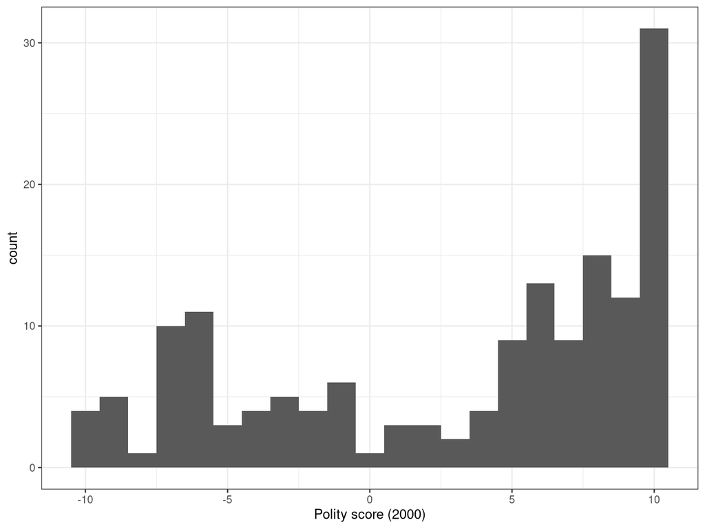

# Example: Improving Polity

- The component scores are often not independent of one another
  - For example, “xropen” captures the extent to which executive elections are “open” but it’s partially constrained by “xrcomp”, the competitiveness of executive recruitment.

```r
table(polity2000$xropen, polity2000$xrcomp)
```

```
     0  1  2  3
  0 24  0  0  0
  1  0  6  0  0
  2  0  5  0  0
  3  0  0  2  0
  4  0 20 33 65
```

# Example: Improving Polity

- **Trier and Jackman (2008)** settle on three ordinal indices constructed from the Polity components as the latent “tasks” for their IRT model

```r
table(polity2000$exrec)
```

```
 1  2  3  4  5  6  7  8
 6  5 20 14 10  2 33 65
```

```r
table(polity2000$exconst)
```

```
 1  2  3  4  5  6  7
15 13 26  8 25 18 50
```

```r
table(polity2000$polcomp)
```

```
 1  2  3  4  5  6  7  8  9 10
16 19  7  1  1 18 15 10 35 33
```

- Each of these ordinal indicators is modeled as an expression of some underlying latent “democracy” variable

# Example: Improving Polity

- The model used in the paper is a **two-parameter** ordinal logit.
  - Index country-year by $i$, Polity indicator by $j$, and the $K_j$ ordinal categories by $k$.
  - Latent “democracy” variable $\theta_i$ and latent “item discrimination parameter” $\beta_j$
- The probability of observing a rating for country $i$ on indicator $j$, $Y_{ij}$ is:

$$\begin{align*}
Pr(Y_{ij} = 1) &= F(\tau_{j1} - \theta_i\beta_j)\\
\vdots \\
Pr(Y_{ij} = k) &= F(\tau_{jk} - \theta_i\beta_j) - F(\tau_{j,k-1} - \theta_i\beta_j)\\
\vdots \\
Pr(Y_{ij} = K_j) &= 1 - F(\tau_{j,K_j-1} - \theta_i\beta_j)\\
\end{align*}$$

where $F()$ is the logistic CDF and $\tau_{j1} < \tau_{j2} < \dotsc < \tau_{j, K_j-2} < \tau_{j, K_j-1}$ are a set of ordered cut-points for indicator $j$

# Example: Improving Polity

- Let’s implement this for 2000 in Stan (we could do a full model for the entire Polity dataset, but that takes longer to run)
- First, the data block

```stan
data{
  int<lower=1> N; // number of countries
  array[3] int<lower=1> K; // number of categories per task
  array[N, 3] int<lower=1> Y; // responses to each task (hard-coding 3 tasks)
}
```

# Example: Improving Polity

- For the parameters, we’ll define $\theta$ and $\beta$ as usual…
  - …but we’ll use a trick to re-parameterize the cutpoints to make it easier to put priors on them!

```stan
parameters{
  array[N] real theta; // country scores;
  array[3] real beta; // discrimination parameters;
  array[3] real delta_start; // parameterization of cutpoints;
  vector<lower=0>[K[1]-2] delta1; // parameterization of distances
  vector<lower=0>[K[2]-2] delta2;
  vector<lower=0>[K[3]-2] delta3;
}
```

# Example: Improving Polity

- The cutpoints are **ordered**
  - But we want to put a prior on an **unordered** parameters
  - **Solution**: Put a normal prior on the first cutpoint and then the **distances** between each gap!
  - Use the `transformed parameters` block to generate the ordered `tau`

```stan
transformed parameters{
  ordered[K[1]-1] tau1;
  tau1[1] = delta_start[1];
  tau1[2:] = delta_start[1] + cumulative_sum(delta1);
  ordered[K[2]-1] tau2;
  tau2[1] = delta_start[2];
  tau2[2:] = delta_start[2] + cumulative_sum(delta2);
  ordered[K[3]-1] tau3;
  tau3[1] = delta_start[3];
  tau3[2:] = delta_start[3] + cumulative_sum(delta3);
}
```

# Example: Improving Polity

- Lastly our model using the ordered logistic specification

```stan
model{
  theta ~ normal(0, 1);
  beta ~ normal(0, 3);
  delta_start ~ normal(0, 2.58);
  delta1 ~ exponential(2);
  delta2 ~ exponential(2);
  delta3 ~ exponential(2);
  for (n in 1:N) {
    Y[n,1] ~ ordered_logistic(theta[n] * beta[1], tau1);
    Y[n,2] ~ ordered_logistic(theta[n] * beta[2], tau2);
    Y[n,3] ~ ordered_logistic(theta[n] * beta[3], tau3);
  }
}
```

# Example: Improving Polity

- Pass in the data

```r
polity_data <- list(N = nrow(polity2000), K= apply(polity2000 %>% select(exrec, exconst,polcomp),2,function(x) length(unique(x))),
                  Y= polity2000 %>% select(exrec, exconst,polcomp))
```

- Estimate the model (run 4 chains)
  - **Warning**: This model actually has convergence problems across the different chains

```r
# This model has convergence problems
polity_irt_bad <-  stan(
  model_code = polityirt_model,  # Stan code
  data = polity_data,    # named list of data
  chains = 4,             # number of Markov chains
  warmup = 500,          # number of warmup iterations per chain
  iter = 2500,            # total number of iterations per chain
  cores = 4,              # number of cores (could use one per chain - by default uses however many you have)
  refresh = 0,
  seed = 60637
  )
```

# Example: Improving Polity

- What’s happening here?

```r
traceplot(polity_irt_bad, pars=c("beta"))
```

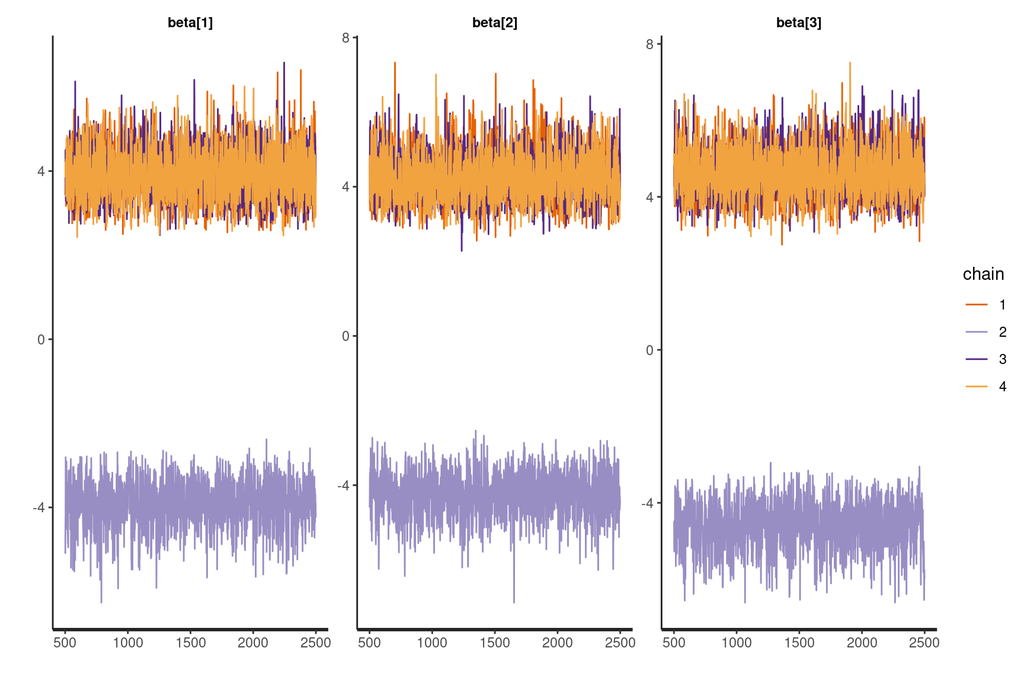

# Example: Improving Polity

- Because the IRT model is identified only up to reflection, the MCMC ends up going to one of two posterior modes
  - $\beta$ is positive and high $\theta$ reflects high democracy
  - or $\beta$ is negative and high $\theta$ reflects high **autocracy**

# Example: Improving Polity

- Essentially, we need to put some additional constraints on the model.
- One easy fix for this version is to make the discrimination parameters **always** positive
  - This is standard for the education/testing IRT model
  - We wouldn’t want this for a voting model, but for the democracy model it’s not unreasonable
  - Instead of a normal prior on $\beta$, we can use a log-normal or half-normal.
- In a voting model, we want to allow for votes to have both a positive and a negative discrimination parameter
  - Some votes have Democrats voting **Yes** and Republicans voting **No**; others have Democrats voting **No** and Republicans voting **Yes**
  - We’ll instead fix some known legislators’ latent ideal points to particular values using a “spike” prior

# Example: Improving Polity

```r
# In this model, we restrict the betas to be positive
polity_irt <-  stan(
  model_code = polityirt_model_fixed,  # Stan code
  data = polity_data,    # named list of data
  chains = 4,             # number of Markov chains
  warmup = 500,          # number of warmup iterations per chain
  iter = 2500,            # total number of iterations per chain
  cores = 4,              # number of cores (could use one per chain - by default uses however many you have)
  refresh = 0,
  seed = 60637
  )
```

# Example: Improving Polity

- Problem solved!

```r
traceplot(polity_irt, pars=c("beta"))
```

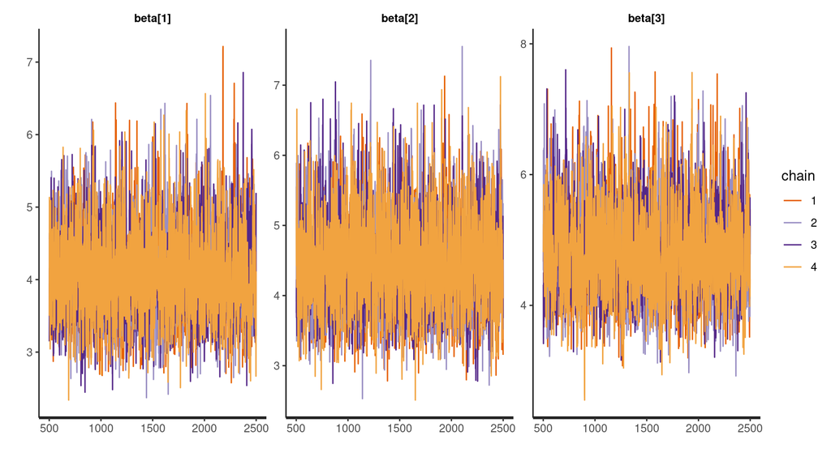

# Example: Improving Polity

- Get the latent democracy scores

```r
democracy_scores <- rstan::extract(polity_irt)$theta
polity2000$pm_irt <- colMeans(democracy_scores)
polity2000 %>% ggplot(aes(x=pm_irt)) + geom_histogram() + xlab("IRT posterior means") + theme_bw()
```

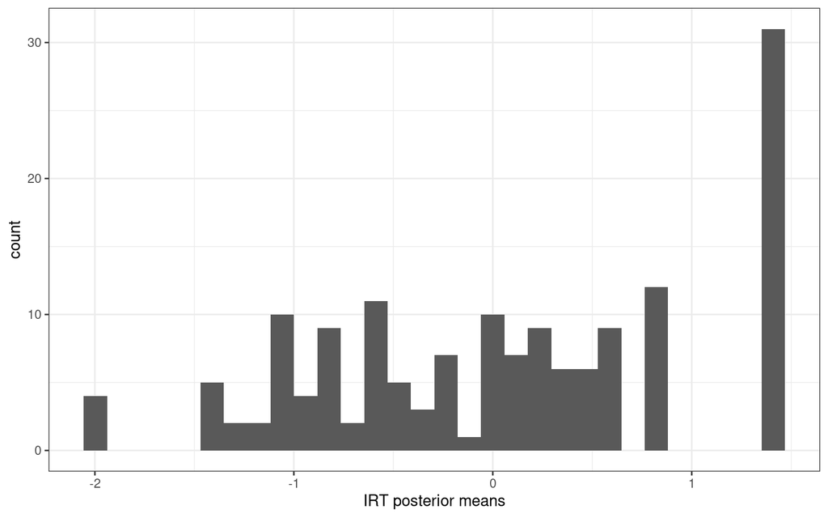

# Example: Improving Polity

- Plot against the “Polity” scores

```r
polity2000 %>% ggplot(aes(x=pm_irt, y=polity2)) + geom_point() + geom_smooth() + xlab("Bayesian IRT Posterior Means") + ylab("Polity V") + theme_bw()
```

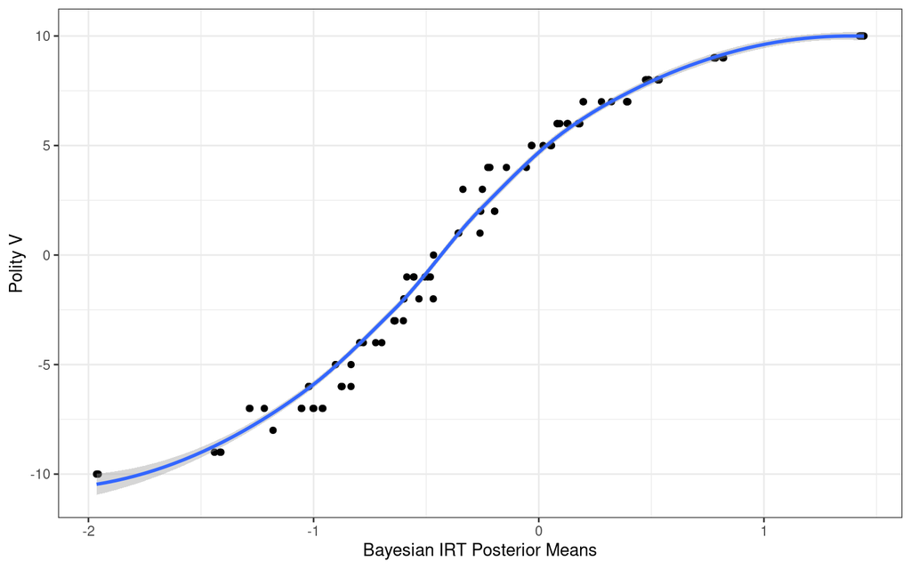

# Example: Improving Polity

- Plot posteriors by country

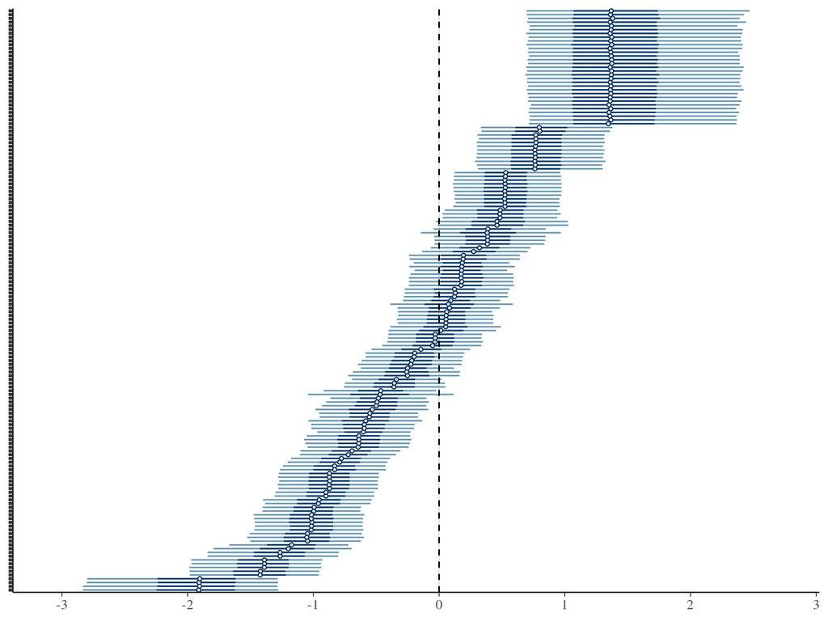

# Example: Improving Polity

- A common classification of states as “democracies” that is commonly used is $\text{Polity} \ge 6$
  - What does that look like for the posteriors of those states?

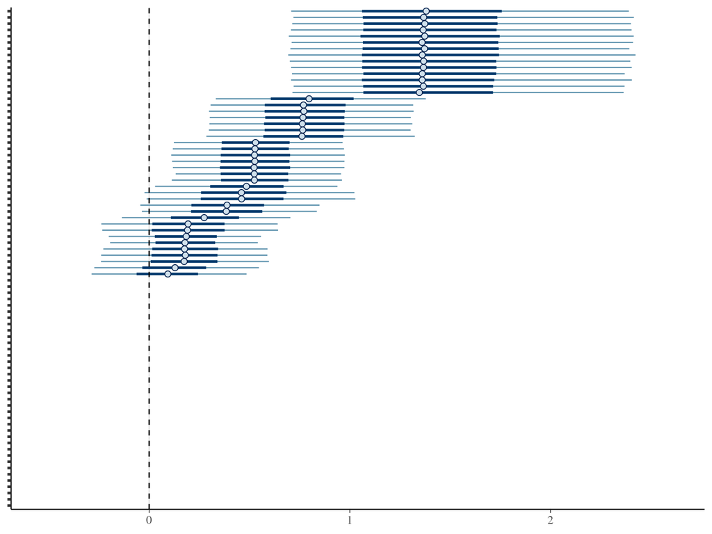

# Example: Improving Polity

- How about the “non-democracies” $\text{Polity} < 6$?

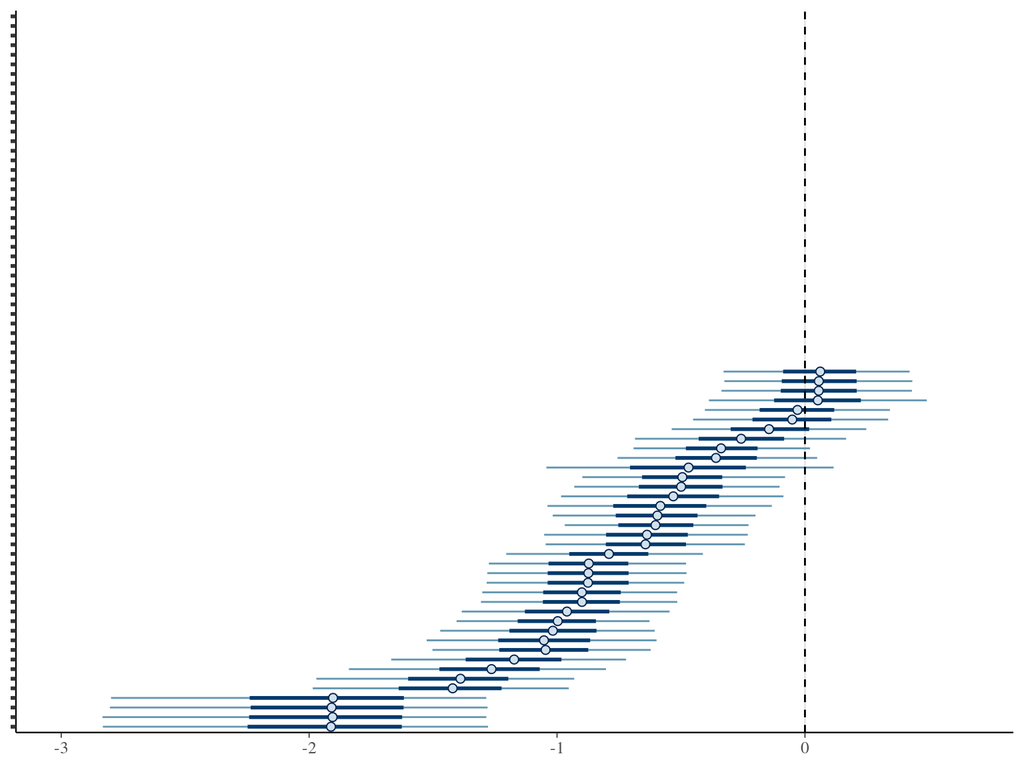

# Example: Improving Polity

- We can also get a sense of what component indices are most driving the ideal points by plotting $\beta_j$

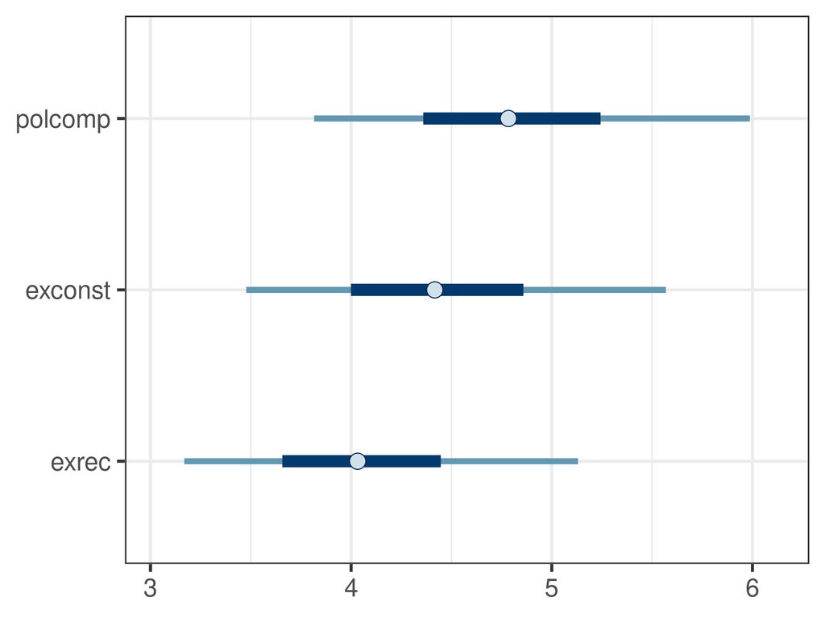

# Dynamic IRT model

- So far, we’ve focused on settings with just one time period.
  - **Jackman and Trier (2008)** estimate latent democracy scores for each year entirely separately.
- But this seems inefficient. The previous year’s latent score is probably a good predictor of this year’s score.
  - How do we incorporate this in the model?
- Put a **random walk prior** on $\theta_i$
  - In political science, first used by **Martin and Quinn (2002)** to study ideology of supreme court justices.
  - Many other applications to different settings (e.g. UNGA voting by **Bailey et. al. (2017)**)

# Dynamic IRT model

- We observe roll call votes for $N$ legislators on $J$ bills across $T$ time periods.
  - $Y_{ijt}$ denotes the choice ($1$ = Yea, $0$ = Nay)
  - Note that not all legislators will vote in every time period, not every bill appears in every time period, etc…
- Same two-parameter set-up as before with a time-specific ideal point $\theta_{it}$. **Martin and Quinn (2002)** use the probit link here.

$$Pr(Y_{ijt} = 1) = F\bigg(\alpha_j + \beta_j\theta_{it}\bigg)$$

# Dynamic IRT model

- Same (diffuse) normal priors on the bill parameters $\beta_j$ and $\alpha_j$
- For the **first** ideal point for legislator $i$ $\theta_{i0}$, we use a standard normal prior.
- But each successive ideal point is assumed to come from a random walk centered on the *previous* ideal point

$$\theta_{it} \sim \mathcal{N}(\theta_{i(t-1)}, \omega^2)$$

- $\omega^2$ is a user-specified “smoothing parameter” – what is our prior belief about how “jumpy” the ideal points are from year-to-year.
  - $\omega^2 \to 0$ is equivalent to a **pooled** IRT model where every legislator has the same ideal point in each session.
  - $\omega^2 \to \infty$ is equivalent to the setting where each time period is analyzed **completely separately**

# Illustration: Supreme Court Ideology

- **Martin and Quinn (2002)** implement an MCMC algorithm for this model.
  - **Imai, Lo and Olmsted (2016)** develop a faster Variational EM algorithm for obtaining the posterior modes.
  - Implemented in the `emIRT` package (along with the Martin and Quinn data)
- Load up the package

```r
library(emIRT)
```

- Load up the Martin and Quinn data

```r
data(mq_data)
```

# Illustration: Supreme Court Ideology

- What does the “data matrix” look like?

```r
mq_data$data.mq$rc[,4]
```

```
     Harlan       Black     Douglas     Stewart    Marshall     Brennan
          0           1           0           0           0           0
      White      Warren       Clark Frankfurter   Whittaker      Burton
          0           0           0           0           0           0
       Reed      Fortas    Goldberg      Minton     Jackson      Burger
          0           0           0           0           0           0
   Blackmun      Powell   Rehnquist     Stevens    O.Connor      Scalia
          0           0           0           0           0           0
    Kennedy      Souter      Thomas    Ginsburg      Breyer    Rutledge
          0           0           0           0           0           0
     Murphy      Vinson      Byrnes  Sutherland     Cardozo    Brandeis
          0           0           0          -1           1           1
     Butler  McReynolds      Hughes   OJRoberts       Stone     Roberts
         -1          -1           1          -1           1           0
      Alito   Sotomayor       Kagan
          0           0           0
```

# Illustration: Supreme Court Ideology

- How about the priors?

```r
mq_data$priors.mq$beta.mu
```

```
     [,1]
[1,]    0
[2,]    0
```

```r
mq_data$priors.mq$beta.sigma
```

```
     [,1] [,2]
[1,]    1    0
[2,]    0    1
```

# Illustration: Supreme Court Ideology

- We use informative priors on some of the $\theta$ values to get identification

```r
mq_data$priors.mq$x.mu0[mq_data$priors.mq$x.mu0 != 0]
```

```
[1] -2  1  3
```

```r
mq_data$priors.mq$x.sigma0[mq_data$priors.mq$x.mu0 != 0]
```

```
[1] 0.1 0.1 0.1
```

Which justices do these correspond to?

```r
rownames(mq_data$data.mq$rc)[mq_data$priors.mq$x.mu0 != 0]
```

```
[1] "Black"     "Stewart"   "Rehnquist"
```

# Illustration: Supreme Court Ideology

- How much smoothing are we doing?

```r
head(mq_data$priors.mq$omega2)
```

```
     [,1]
[1,]  0.1
[2,]  0.1
[3,]  0.1
[4,]  0.1
[5,]  0.1
[6,]  0.1
```

# Illustration: Supreme Court Ideology

- Let’s estimate the model

```r
mq_estimates <- dynIRT(.data = mq_data$data.mq,
                    .starts = mq_data$cur.mq,
                    .priors = mq_data$priors.mq,
                    .control = {list(
                    threads = 1,
                    verbose = TRUE,
                    thresh = 1e-6,
            maxit=500
                    )})
```

```
====================
dynIRT: Dynamic IRT via Variational Inference

Iteration: 50
    Done in 51 iterations, using 1 threads.
====================
```

```r
## Delete point estimates of 0, which are justices missing from that session
mq_results <- c(t(mq_estimates$means$x))
mq_results[mq_results==0] <- NA
mq_results <- na.omit(mq_results)
```

# Illustration: Supreme Court Ideology

- Let’s make a plot

```r
justice_df <- data.frame(justices = rownames(mq_data$data.mq$rc))
justice_df$justice_id <- 1:nrow(justice_df)
justice_df$startsession <- mq_data$data.mq$startlegis[,1]
justice_df$endsession <- mq_data$data.mq$endlegis[,1]
justice_df
```

```
      justices justice_id startsession endsession
1       Harlan          1           17         33
2        Black          2            0         33
3      Douglas          3            1         37
4      Stewart          4           21         43
5     Marshall          5           30         53
6      Brennan          6           19         52
7        White          7           24         55
8       Warren          8           16         31
9        Clark          9           12         29
10 Frankfurter         10            1         24
11   Whittaker         11           19         24
12      Burton         12            8         20
13        Reed         13            0         19
14      Fortas         14           28         31
```

[output cut: 31 more lines]

# Illustration: Supreme Court Ideology

- Let’s make a plot

```r
results_df <- data.frame(justices = mq_data$justiceName, idealpoints = mq_results)
results_df <- left_join(results_df, justice_df, by="justices")
results_df <- results_df %>% group_by(justices) %>% mutate(session = (row_number() - 1) + startsession)
results_df
```

```
# A tibble: 697 × 6
# Groups:   justices [45]
   justices idealpoints justice_id startsession endsession session
   <chr>          <dbl>      <int>        <dbl>      <dbl>   <dbl>
 1 Harlan         0.432          1           17         33      17
 2 Harlan         0.714          1           17         33      18
 3 Harlan         0.900          1           17         33      19
 4 Harlan         1.06           1           17         33      20
 5 Harlan         1.07           1           17         33      21
 6 Harlan         1.09           1           17         33      22
 7 Harlan         1.03           1           17         33      23
 8 Harlan         1.17           1           17         33      24
 9 Harlan         1.14           1           17         33      25
10 Harlan         1.09           1           17         33      26
# ℹ 687 more rows
```

# Illustration: Supreme Court Ideology

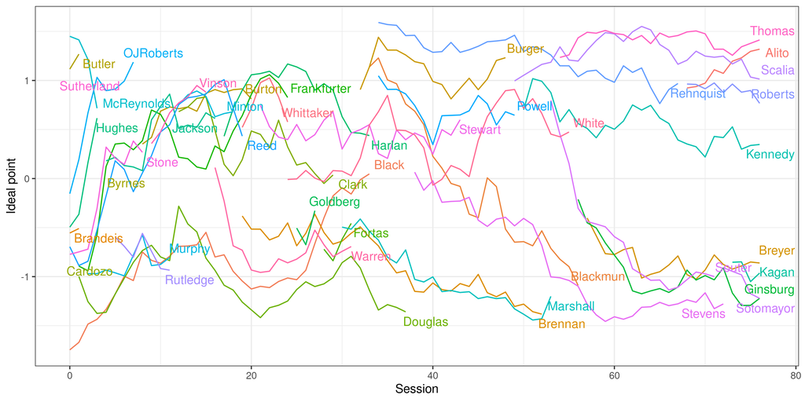

# Illustration: Supreme Court Ideology

- What happens when we use a lower smoothing variance?

```r
mq_data$priors.mq.strong <- mq_data$priors.mq
mq_data$priors.mq.strong$omega2[,1] <- .001

mq_estimates_heavysmooth <- dynIRT(.data = mq_data$data.mq,
                    .starts = mq_data$cur.mq,
                    .priors = mq_data$priors.mq.strong,
                    .control = {list(
                    threads = 1,
                    verbose = TRUE,
                    thresh = 1e-6,
            maxit=500
                    )})
```

```
====================
dynIRT: Dynamic IRT via Variational Inference

    Done in 45 iterations, using 1 threads.
====================
```

```r
## Delete point estimates of 0, which are justices missing from that session
mq_results_heavysmooth <- c(t(mq_estimates_heavysmooth$means$x))
mq_results_heavysmooth[mq_results_heavysmooth==0] <- NA
mq_results_heavysmooth <- na.omit(mq_results_heavysmooth)
results_df$idealpoint_heavysmooth <- mq_results_heavysmooth
```

# Illustration: Supreme Court Ideology

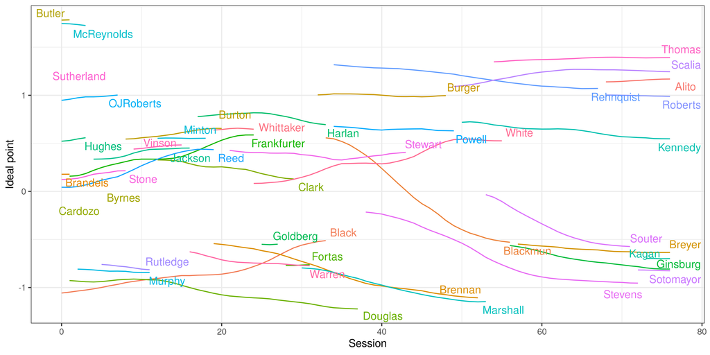

# Summary

- Like clustering models, Item Response Theory (IRT) models treat the outcome as a function of a **latent variable**
  - However, in IRT, the **latent variable** is typically continuous rather than a discrete
- As with clustering, imagine a regression model with **unknown regressors**
  - Our goal is to draw inferences about these regressors under the model structure.
- Inference algorithms leverage the fact that **conditional** on the latent regressors, the model has a familiar structure (e.g. logistic regression)
  - But note similar identifiability problems as clustering (invariance to rotation/reflection)
- **Careful!** - Results dependent on model structure!
  - Interpretation of the model parameters is ultimately up to the researchers - no inherent “meaning” to the latent scale.

# Bonus: Matrix factorization

- The IRT models we’ve discussed in this class can be considered part of a broader class of **latent factor** models
  - Take **high-dimensional data** and represent it in a **lower-dimensional** space
- Tons of related applications!
  - Network models
  - Word embeddings
- A common way of thinking about this problem is in terms of approximating a **matrix** (or **tensor**) using a **lower-rank** matrix
  - Low-rank matrices can be decomposed into the outer product of two matrices representing the lower-dimensional **factors**

# Matrix factorization

- Consider an $m \times n$ matrix $\mathbf{A}$

  $$\mathbf{A} = \begin{bmatrix}
  a_{11} & a_{12} & \cdots & a_{1n} \\
  a_{21} & a_{22} & \cdots & a_{2n} \\
  \vdots & \vdots & \ddots & \vdots \\
  a_{m1} & a_{m2} & \cdots & a_{mn}
  \end{bmatrix}$$
- We can (for example) think of the matrix of **votes** by **legislators**
  - Or observations of **ties** on a network!
  - Or interactions between states

# Matrix factorization

```r
rollcall <- read_csv("data/H118_votes.csv")
rollcall <- rollcall %>% mutate(vote = case_when(cast_code == 1 ~ 1,
                                                 cast_code == 6 ~ -1,
                                                 cast_code == 7 ~ 0,
                                                 cast_code == 9 ~ 0))
members <- read_csv("data/H118_members.csv")
rollcall <- rollcall %>% left_join(members, by="icpsr")
rollcall_matrix <- as.matrix(rollcall %>% select(rollnumber, bioname, vote) %>% pivot_wider(names_from = bioname, values_from = vote) %>% select(-rollnumber))
rollcall_matrix[is.na(rollcall_matrix)] <- 0
```

- We’ll look at the voting records of the 118th U.S. Congress

```r
rollcall_matrix[1:6, 1:6]
```

```
     ROGERS, Harold Dallas (Hal) SMITH, Christopher Henry HOYER, Steny Hamilton
[1,]                          -1                       -1                     1
[2,]                          -1                       -1                     1
[3,]                          -1                       -1                     1
[4,]                          -1                       -1                     1
[5,]                          -1                       -1                     1
[6,]                          -1                       -1                     1
     KAPTUR, Marcia Carolyn (Marcy) MFUME, Kweisi PELOSI, Nancy
[1,]                              1             1             1
[2,]                              1             1             1
[3,]                              1             1             1
[4,]                              1             1             1
[5,]                              1             1             1
[6,]                              1             1             1
```

- What’s the dimensionality?

```r
dim(rollcall_matrix)
```

```
[1] 1235  451
```

# Singular Value Decomposition (SVD)

- Every real matrix has the property that it can be **decomposed** into the product of two matrices of **orthogonal vectors** and a matrix of **singular values**

  $$\mathbf{A} = \mathbf{U} \mathbf{\Sigma} \mathbf{V}^{\prime}$$
- $\mathbf{U}$ is an $m \times m$ matrix of orthogonal column vectors
- $\mathbf{V}$ is an $n \times n$ matrix of orthogonal column vectors
- $\mathbf{\Sigma}$ is an $m \times n$ **diagonal** matrix of singular values ordered by size.
- An alternative way of writing this would be to think of **summing** over the rank-1 matrices created by the outer product of the row and column vectors of $\mathbf{U}$ and $\mathbf{V}$, scaled by the singular value $\sigma$

  $$\mathbf{A} = \sum_{i=1}^{\text{min}(m, n)} \sigma_i \mathbf{u}_i\mathbf{v}_i^{\prime}$$

# Singular Value Decomposition

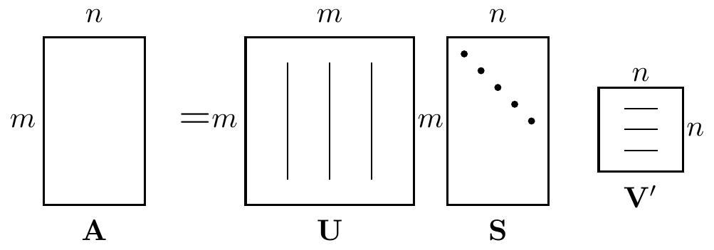

# Low Rank Approximation

- We can use the SVD to obtain a **low rank** approximation of $A$.
  - Given a choice of rank $k << m,n$, our **best approximation** of $A$ is to just take the first $k$ largest singular values and the corresponding elements of $U$ and $V$

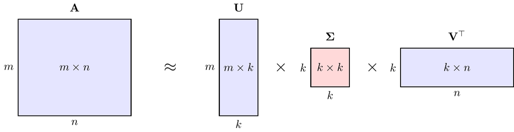

# Low Rank Approximation

- Let’s illustrate this with our voting matrix (and provide some intuition for what the low-rank matrices represent)
  - Start with the SVD of our voting matrix

```r
rollcall_svd <- svd(rollcall_matrix)
```

# Low Rank Approximation

- Our first column of $u$ has as many elements as **votes**
- Our first column of $v$ has as many elements as **legislators**

```r
u_1 <- rollcall_svd$u[,1]
v_1 <- rollcall_svd$v[,1]
names(v_1) <- colnames(rollcall_matrix)
```

# Low Rank Approximation

- Let’s plot a histogram of that first element of $v$ - what does this look like?

```r
hist(v_1, main = "First latent legislator factor")
```

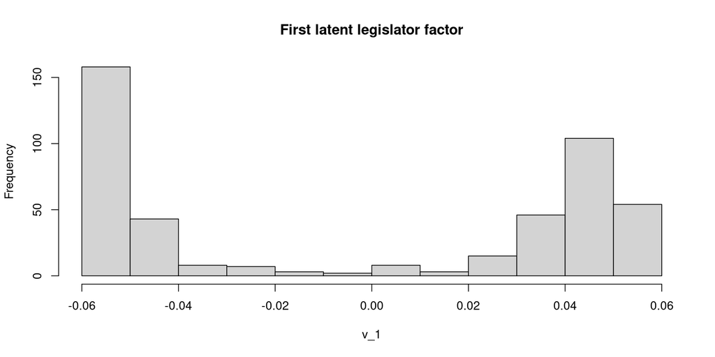

# Low Rank Approximation

- Which legislators are “low” on the factor?

```r
head(v_1[order(v_1)], 20)
```

```
 CLARK, Katherine M.         TOKUDA, Jill     MCGARVEY, Morgan
             -0.0561              -0.0560              -0.0560
CLARKE, Yvette Diane   McGOVERN, James P.   BROWN, Shontel  M.
             -0.0559              -0.0559              -0.0558
         LEE, Summer       NEGUSE, Joseph         TAKANO, Mark
             -0.0558              -0.0557              -0.0556
      FROST, Maxwell        BALINT, Becca     WILLIAMS, Nikema
             -0.0556              -0.0556              -0.0556
     McCOLLUM, Betty       DeGETTE, Diana            CHU, Judy
             -0.0556              -0.0556              -0.0555
    SCOTT, Robert C.    UNDERWOOD, Lauren    RASKIN, Jamie Ben
             -0.0555              -0.0554              -0.0554
 CLYBURN, James Enos     JEFFRIES, Hakeem
             -0.0554              -0.0554
```

- Which legislators are “high” on the factor?

```r
head(v_1[order(-v_1)], 20)
```

```
    BRECHEEN, Josh     CLOUD, Michael    CLINE, Benjamin       MOORE, Barry
            0.0543             0.0541             0.0538             0.0537
    BURLISON, Eric        SELF, Keith TIFFANY, Thomas P.      COLLINS, Mike
            0.0537             0.0535             0.0534             0.0534
HARSHBARGER, Diana   CLYDE, Andrew S.        OGLES, Andy      NORMAN, Ralph
            0.0533             0.0532             0.0532             0.0532
  HAGEMAN, Harriet        HERN, Kevin        JORDAN, Jim    MILLER, Mary E.
            0.0530             0.0530             0.0530             0.0527
       BEAN, Aaron       ROY, Charles   FULCHER, Russell       PERRY, Scott
            0.0527             0.0526             0.0526             0.0525
```